# Tree Practice (Regression)

Jinwoo Chung

4/23/2018

## Table of Contents

1. Setup
2. Separate Train and Test Data
3. Generate Full Tree Model
4. Evalute Full Tree Model
5. Use cp values to prune (**Conditional** default cp = 0.01, if the value is too big, what to do next?)

### Setup

```r
library(pacman)
pacman::p_load(dplyr,ROCR,caret)
main <- read.csv("https://archive.ics.uci.edu/ml/machine-learning-databases/abalone/abalone.data", header = FALSE)
names(main) <- c('Sex', 'Length', 'Diameter', 'Height', 'Whole weight', 'Shucked weight', 'Viscera weight', 'Shell weight', 'Rings')
glimpse(main)
```

```
## Observations: 4,177
## Variables: 9
## $ Sex              <fct> M, M, F, M, I, I, F, F, M, F, F, M, M, F, F, ...
## $ Length           <dbl> 0.455, 0.350, 0.530, 0.440, 0.330, 0.425, 0.5...
## $ Diameter         <dbl> 0.365, 0.265, 0.420, 0.365, 0.255, 0.300, 0.4...
## $ Height           <dbl> 0.095, 0.090, 0.135, 0.125, 0.080, 0.095, 0.1...
## $ `Whole weight`   <dbl> 0.5140, 0.2255, 0.6770, 0.5160, 0.2050, 0.351...
## $ `Shucked weight` <dbl> 0.2245, 0.0995, 0.2565, 0.2155, 0.0895, 0.141...
## $ `Viscera weight` <dbl> 0.1010, 0.0485, 0.1415, 0.1140, 0.0395, 0.077...
## $ `Shell weight`   <dbl> 0.150, 0.070, 0.210, 0.155, 0.055, 0.120, 0.3...
## $ Rings            <int> 15, 7, 9, 10, 7, 8, 20, 16, 9, 19, 14, 10, 11...
```

### Separate Train and Test Data

```r
# setting seed
set.seed(77)
# splitting data
index.train <- sample(1:nrow(main), round(nrow(main) * 0.8))
train <- main[index.train,]
test <- main[-index.train,]
head(train)
```

```
##      Sex Length Diameter Height Whole weight Shucked weight Viscera weight
## 1217   I  0.310    0.225  0.070       0.1055         0.4350         0.0150
## 2997   F  0.620    0.500  0.170       1.1480         0.5475         0.2200
## 3601   I  0.175    0.125  0.040       0.0280         0.0095         0.0080
## 3966   I  0.295    0.220  0.070       0.1365         0.0575         0.0295
## 3084   I  0.225    0.170  0.050       0.0515         0.0190         0.0120
## 1909   M  0.575    0.475  0.145       0.8570         0.3665         0.1730
##      Shell weight Rings
## 1217       0.0400     5
## 2997       0.3315    10
## 3601       0.0090     4
## 3966       0.0350     6
## 3084       0.0170     4
## 1909       0.2690     9
```

### Generate Full Tree Model

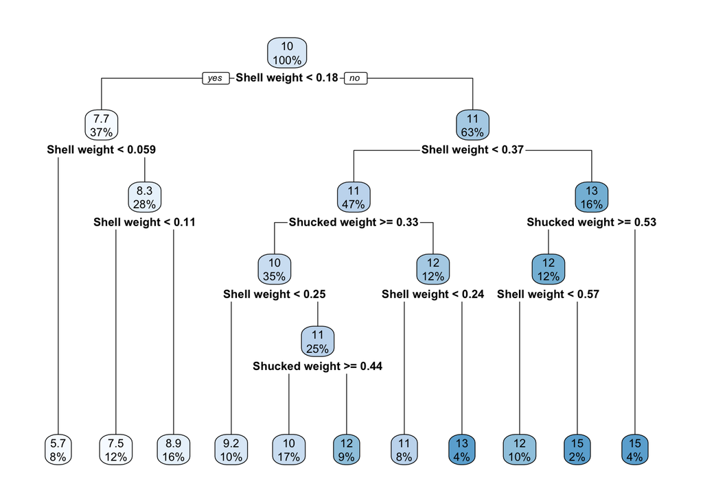

```r
tm.train <- rpart::rpart(Rings ~ ., method="anova", data = train)
# use summary for a text output
# summary(tm.train)
# using rpart.plot for a visual output
rpart.plot::rpart.plot(tm.train)
```

### Evalute Full Tree Model

```r
prediction <- predict(tm.train, test)
# using rmse as a indicator for the model
sqrt(mean((prediction - test$Rings)^2))
```

```
## [1] 2.554326
```

### Use cp values to prune (**Conditional** default cp = 0.01, if the value is too big, what to do next?)

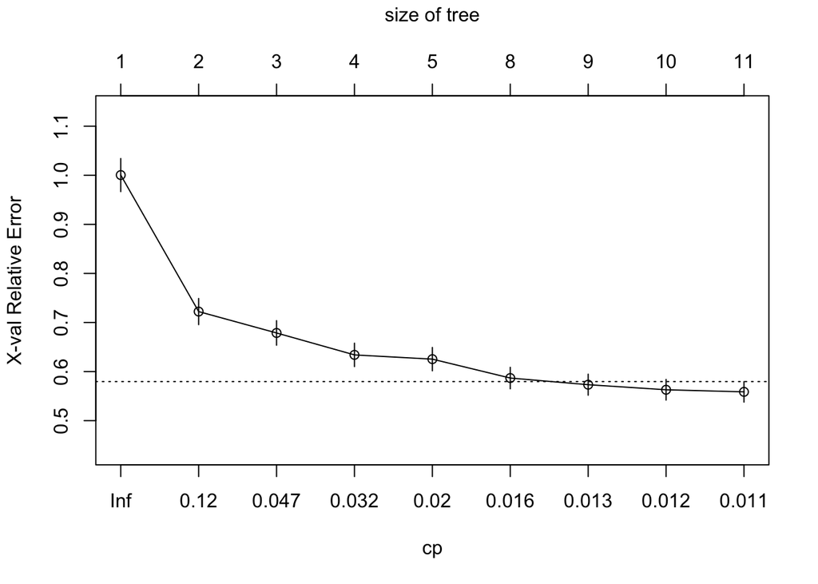

```r
rpart::plotcp(tm.train)
```

```r
# finding minimum xerror
tm.train$cptable[which.min(tm.train$cptable[,"xerror"]),"CP"]
```

```
## [1] 0.01
```

By looking at the graph, it starts to lose its relative error decrease rate around 0.032, but it still goes down slightly. Seems like it may go further down than 0.011 (when minimum for xerror is calcualted, the value returns 0.01, so its not much improvement). Choosing cp = 0.013

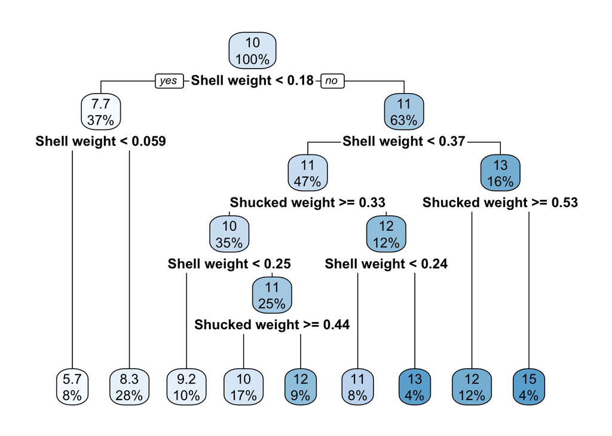

```r
tm.cp.train <- rpart::rpart(Rings ~ ., data = train, cp=0.013)
rpart.plot::rpart.plot(tm.cp.train)
```

Evaluating the result of when cp=0.013

```r
prediction.cp <- predict(tm.cp.train, test)
# using rmse as a indicator for the model
sqrt(mean((prediction.cp - test$Rings)^2))
```

```
## [1] 2.635291
```

The Actual RMSE goes up, meaning the default cp value 0.01 had better result. Since xerror was minimum at 0.01, seems like that has caused the RMSE to be the optimal at 0.01. Cannot judge that this ML model is bad since there are no other ML used that can be compared to this model. However, I feel that it is not a very good model to use.